# Assignment 7: Visualization - Some aspects of ggplot2

*How to do it?*:

- Open the Rmarkdown file of this assignment (link) in Rstudio.
- Right under each **question**, insert a code chunk (you can use the hotkey `Ctrl + Alt + I` to add a code chunk) and code the solution for the question.
- `Knit` the rmarkdown file (hotkey: `Ctrl + Alt + K`) to export an html.
- Publish the html file to your Githiub Page.

*Submission*: Submit the link on Github of the assignment to Canvas

### I. Questions on Your Selected Data

Use the data of your own. Produce the following types of plots and comment on each plot. Plots should be meaningful. If you use the data we used in class, make sure the plots are not the same as the ones in the slides. All plots should have title, caption, appropriate labels on x and y-axis.

```r
library(tidyverse)
library(ggplot2)
library(lubridate)
library(knitr)
df <- read_csv('https://bryantstats.github.io/math421/titanic.csv')
```

1. Make a plot using `face_wrap` by one categorical variable (`face_wrap(~variable1)`)

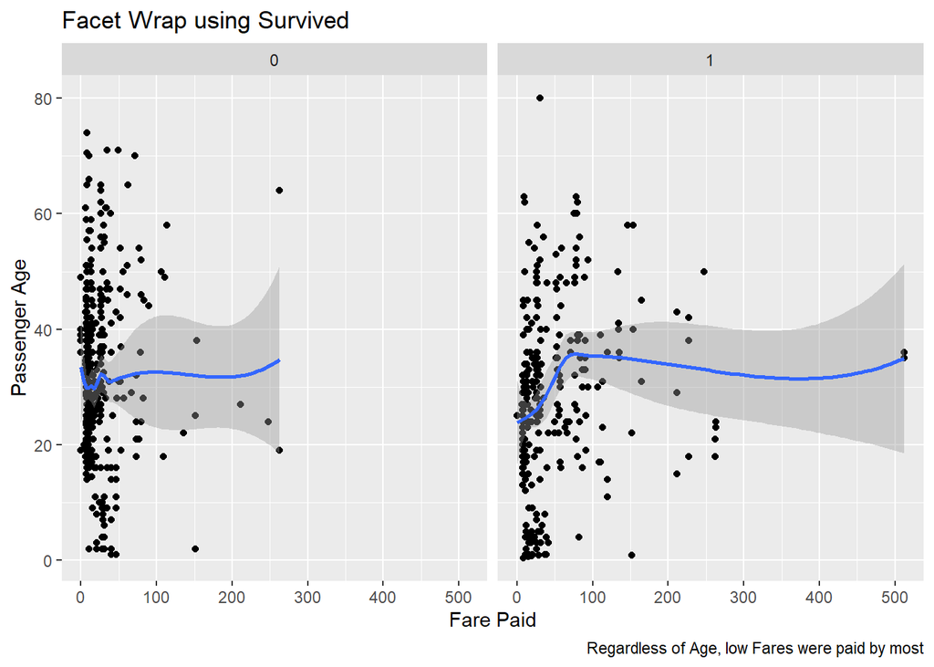

```r
df %>% ggplot(mapping = aes(x=Fare, y=Age)) + geom_point() + geom_smooth() + facet_wrap(~Survived) + labs(x = 'Fare Paid', y = 'Passenger Age', title = 'Facet Wrap using Survived', caption = 'Regardless of Age, low Fares were paid by most')
```

2. Make a plot using `face_wrap` by two categorical variables (`face_wrap(variable1~variable2)`)

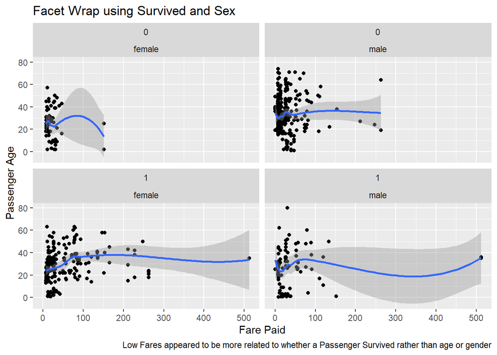

```r
df %>% ggplot(mapping = aes(x=Fare, y=Age)) + geom_point() + geom_smooth() + facet_wrap(Survived~Sex) + labs(x = 'Fare Paid', y = 'Passenger Age', title = 'Facet Wrap using Survived and Sex', caption = 'Low Fares appeared to be more related to whether a Passenger Survived rather than age or gender')
```

3. Make a plot using `position ='jitter'`.

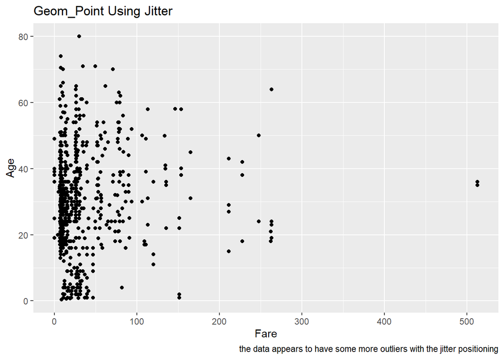

```r
df %>% ggplot() + geom_point(mapping=aes(x=Fare, y=Age), position='jitter') + labs(title = 'Geom_Point Using Jitter', caption = 'the data appears to have some more outliers with the jitter positioning')
```

4. Make a plot using `position ='dodge'`.